# Trabajando con la EPH

Juan Videla y Juan Pablo Costa

# *PRIMERA PARTE*

En este informe trabajaremos con las bases de la EPH-INDEC, utilizando el paquete ‘eph’

```r
library(dplyr)
library(eph)
library(tidyr)
library(tidyverse)
```

```r
base_hogar_2019_01_02 <- get_microdata(year = 2019,
                                 trimester = 1:2,
                                 type = "hogar") %>%
  organize_labels(., type = "hogar")
```

Luego la base individual del 1° trimestre 2019 Vemos que es una base que tiene 177 variables de 59.258 observaciones

```r
base_individual_2019_01 <- get_microdata(year = 2019,
                                 trimester = 1,
                                 type = "individual") %>%
  organize_labels(., type = "individual")
```

```r
base_unificada_2019_01 <- get_microdata(year = 2019,
                                        trimester = 1,
                                        type = "individual")
```

Ambas bases tienen variables numéricas codificadas (en su gran mayoría integer), y una variable especial CODUSU. Tienen datos faltantes donde no corresponde la respuesta, por ejemplo en saltos de preguntas.

Primero calculamos la proporción de varones y mujeres

```r
proporcion_sexo <- base_individual_2019_01 %>%
  summarise("Proporcion de varones" = mean(CH04==1))

knitr::kable(proporcion_sexo)
```

| Proporcion de varones |
| --- |
| 0.483451 |

```r
base_individual_2019_01 %>%
  summarise(max(CH06, na.rm = FALSE), min(CH06, na.rm = FALSE))
```

```
## # A tibble: 1 x 2
##   `max(CH06, na.rm = FALSE)` `min(CH06, na.rm = FALSE)`
##                        <int>                      <int>
## 1                        103                         -1
```

Vamos a estimar ingresos medios y medianos de trabajadores en relación de dependencia.

```r
ingresos_general <- base_individual_2019_01 %>%
  filter(CAT_OCUP == 3 | CAT_OCUP == 1 & ESTADO == 1) %>%
  group_by(CAT_OCUP) %>%
  summarise("Promedio de ingresos" = mean(P47T), median(P47T))
knitr::kable(ingresos_general)
```

| CAT_OCUP | Promedio de ingresos | median(P47T) |
| --- | --- | --- |
| 1 | 23808.42 | 15000 |
| 3 | 19748.71 | 16000 |

Ahora estimamos ingresos medios y medianos de patrones

```r
ingresos_patrones <- base_individual_2019_01 %>%
  filter(CAT_OCUP == 1 & ESTADO == 1) %>%
  summarise(mean(P47T), median(P47T))
knitr::kable(ingresos_patrones)
```

| mean(P47T) | median(P47T) |
| --- | --- |
| 23808.42 | 15000 |

Vamos a estimar brecha de género en ingresos en trabajadores en relación de dependencia.

```r
brecha_ingresos <- base_individual_2019_01 %>%
  filter(CAT_OCUP == 3 & ESTADO == 1) %>%
  group_by(CH04) %>%
  summarise(mean(P47T), median(P47T))
```

Para observarlo con mayor claridad lo graficamos en función de la edad, viendo como los puntos celestes - mujeres- se ubican en general más hacia el sector de menor ingresos que los rojos - varones-.

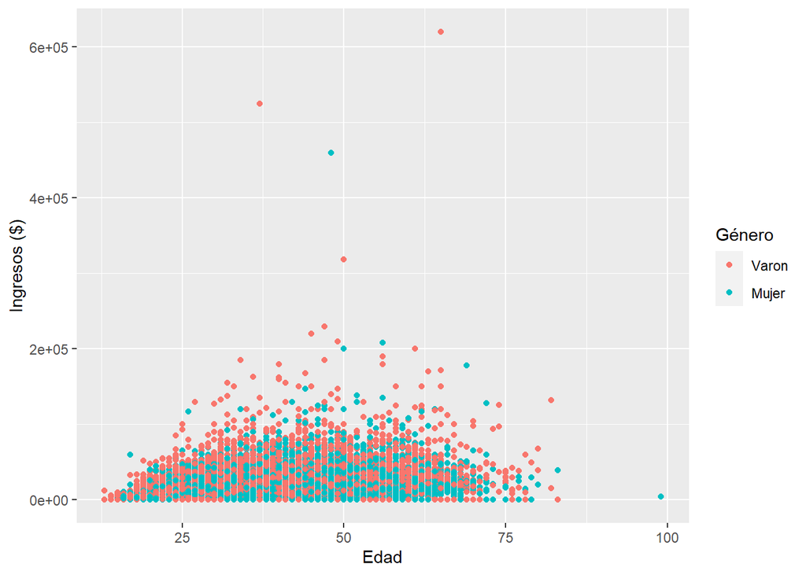

```r
base_individual_2019_01 %>%
    filter(CAT_OCUP == 3 & ESTADO == 1) %>%
  ggplot(aes(CH06, P47T))+
  labs(x = "Edad", y = "Ingresos ($)", color = "Género")+
  geom_point(aes(color = factor(CH04)))
```

Aquí tratamos de graficar edad e ingresos, y que los puntos sean de color diferente de acuerdo al aglomerado. La distribución parece indicar mayor proporción de ingresos altos en CABA respecto a GBA. También pareciera indicar una población relativamente más envejecida en CABA respecto a GBA.

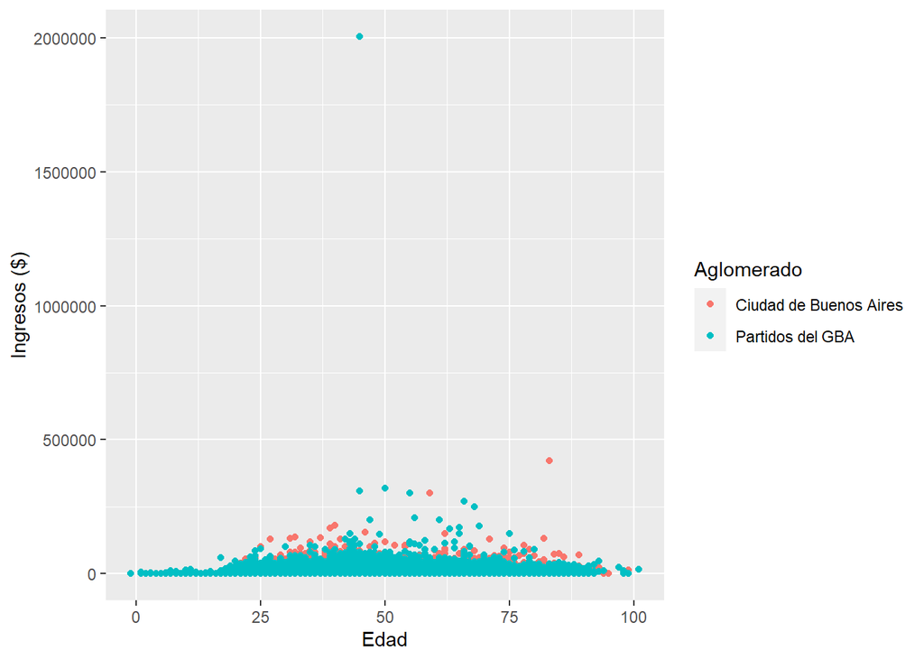

```r
base_individual_2019_01 %>%
  filter(AGLOMERADO == 32 | AGLOMERADO == 33) %>%
  ggplot(aes(CH06, P47T))+
  labs(x = "Edad", y = "Ingresos ($)", color = "Aglomerado")+
  geom_point(aes(color = factor(AGLOMERADO)))
```

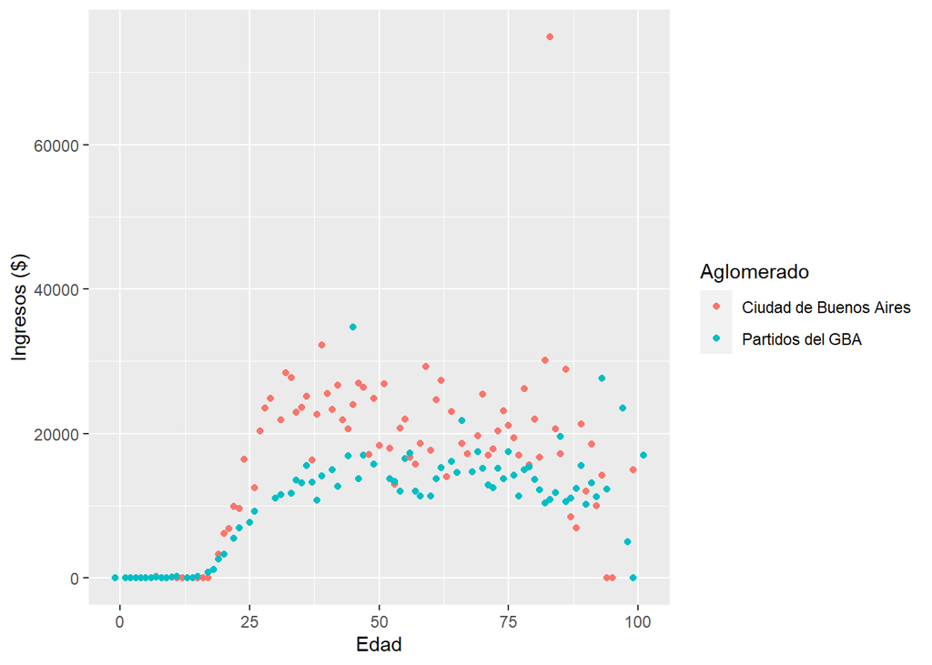

```r
base_individual_2019_01 %>%
  filter(AGLOMERADO == 32 | AGLOMERADO == 33) %>%
  group_by(CH06, AGLOMERADO) %>%
    summarise(ingreso_promedio = mean(P47T)) %>%
  ggplot(aes(CH06, ingreso_promedio))+
  labs(x = "Edad", y = "Ingresos ($)", color = "Aglomerado")+
  geom_point(aes(color = factor(AGLOMERADO)))
```